# AR(1) processes

### Loading packages, defining colors and using data

```r
rm(list = ls())
library(reshape2)
library(base)
library(ggplot2)
library(grid)
library(scales)
library(stringr)
library(tidyverse)

# should graphs be exported to pdf
export_pdf <- FALSE

# define some colors
mygreen <- "#00BA38"
myblue  <- "#619CFF"
myred   <- "#F8766D"

# standard deviation of epsilon
sd_eps = 0.1
```

### Impulse response functions for different AR(1) coefficients

We now want to plot different impulse response functions of an AR(1) process with different degrees of persistence $\rho$. To this end, we simulate the behavior of the AR(1) process for 20 periods. We therefore create an array `x` that contains each of these periods (quarters) and start a data frame `dat` that contains the periods in the first column. In a second step, we calculate the behavior of the AR(1) for persistence values in between $-0.9$ and $0.9$. We assume that the process receives a one standard deviation shocks (the *impulse*) at period $t = 1$. In any successive period, there is no additional shock, but the original shock just fades out at the rate $\rho$ (*response*).

```r
# generate sequence of 20 quarters
x <- seq(1, 20, 1)
dat <- data.frame(quarter=x)

# iterate over different values
i <- 1
for(rho in c(-0.9, -0.5, 0, 0.5, 0.9)) {
  dat[paste("rho", i, sep="")] <- sd_eps*rho^c(0:(length(x)-1))
  i <- i+1
}
```

We now plot the impulse response functions for all non-negative values of $\rho$ simulated above. It is easy to see that the persistence parameter $\rho$ is the central variable that governs the *memory* of the process. High levels of persistence lead the initial shock to persist (to be remembered) for a high number of periods. Under a persistence of $\rho = 0$, the shock only lasts for one period and then is immediately gone. Note that in the absence of shocks, the AR(1) process (with mean $0$) is just a first-order linear difference equation with $a = \rho$ and $b = 0$.

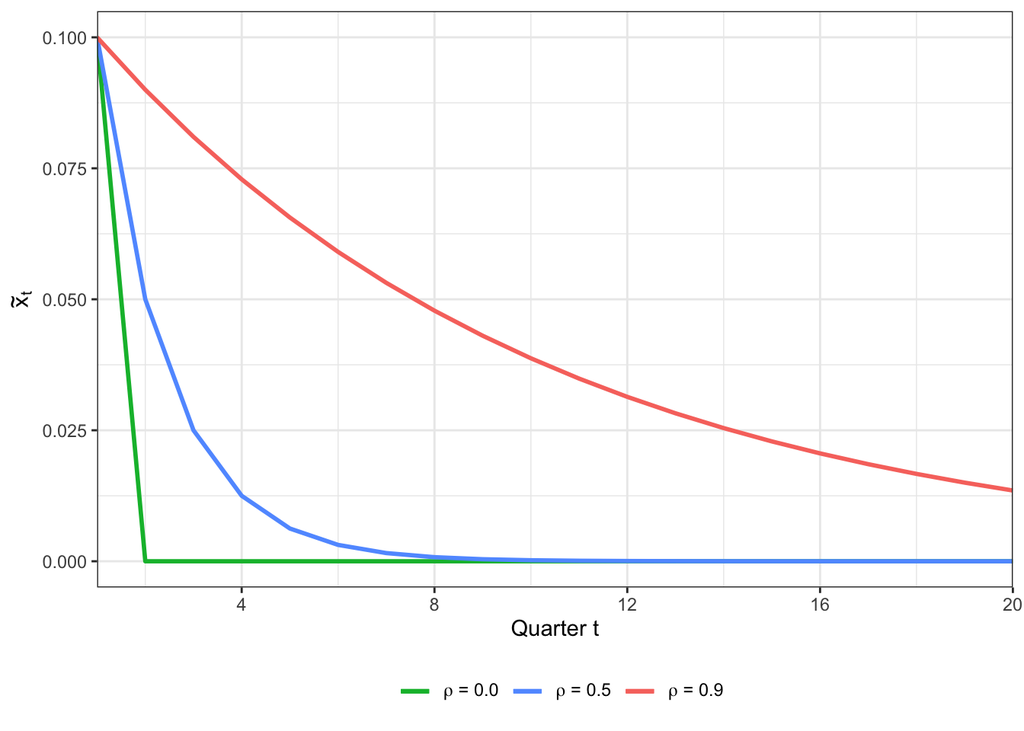

```r
# create plot for positive rhos
myplot <- ggplot(data = dat) +
  geom_line(aes(x=quarter, y=rho3, color="l1"), linewidth=1) +
  geom_line(aes(x=quarter, y=rho4, color="l2"), linewidth=1) +
  geom_line(aes(x=quarter, y=rho5, color="l3"), linewidth=1) +
  scale_x_continuous(breaks=seq(0, 20, 4), expand=c(0, 0)) +
  scale_y_continuous(breaks=seq(0, 0.1, 0.025)) +
  labs(x = "Quarter t",
       y = expression(tilde(x)[t])) +
  scale_color_manual(breaks = c("l1", "l2", "l3"),
                     labels = c(expression(paste(rho," = 0.0")), expression(paste(rho," = 0.5")), expression(paste(rho," = 0.9"))),
                     values = c(mygreen, myblue, myred), name='') +
  theme_bw() +
  theme(legend.position="bottom")

# print the plot
print(myplot)
```

Remembering the convergence properties of the linear difference equation, it is not surprising that the impulse response function is alternating around zero when ever $\rho < 0$. This can be seen from the following graph.

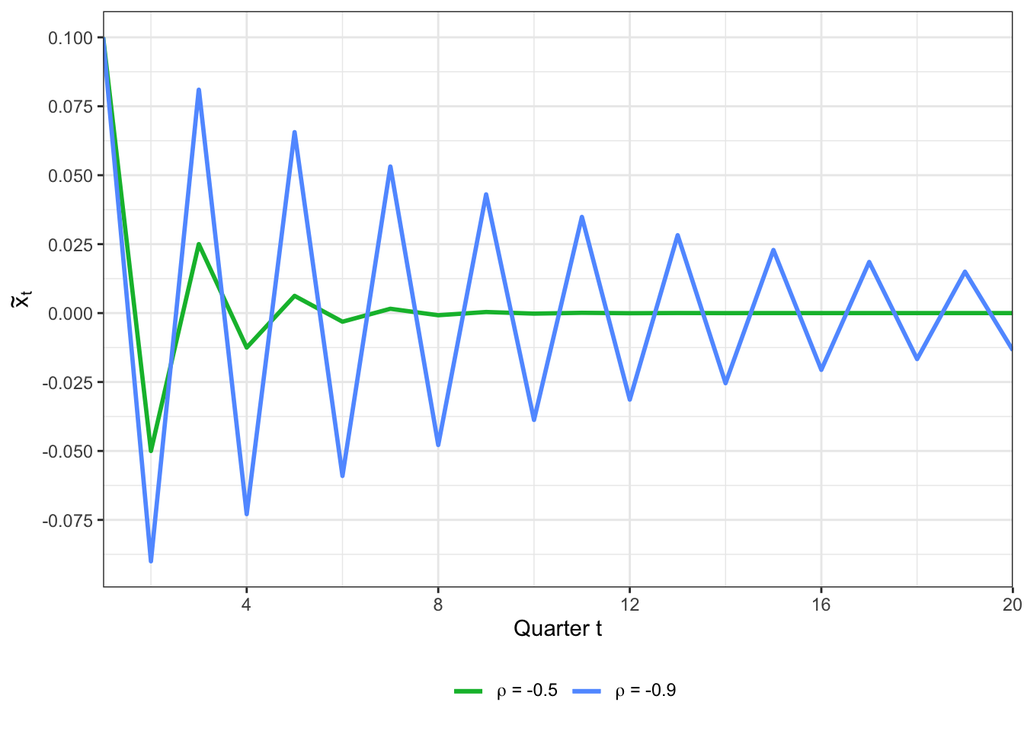

```r
# create plot for negative rhos
myplot <- ggplot(data = dat) +
  geom_line(aes(x=quarter, y=rho2, color="l1"), linewidth=1) +
  geom_line(aes(x=quarter, y=rho1, color="l2"), linewidth=1) +
  scale_x_continuous(breaks=seq(0, 20, 4), expand=c(0, 0)) +
  scale_y_continuous(breaks=seq(-0.1, 0.1, 0.025)) +
  labs(x = "Quarter t",
       y = expression(tilde(x)[t])) +
  scale_color_manual(breaks = c("l1", "l2"),
                     labels = c(expression(paste(rho," = -0.5")), expression(paste(rho," = -0.9"))),
                     values = c(mygreen, myblue), name='') +
  theme_bw() +
  theme(legend.position="bottom")

# print the plot
print(myplot)
```

### Distribution for $\log(X_t)$ for different values of $\rho$

In this graph, we calculate the unconditional distribution (density function) for $\log(X_t)$, which is just a normal distribution with mean $\mu = 0$ and an unconditional variance of $\sigma_2 = \frac{\sigma_\epsilon^2}{1-\rho^2}$, meaning a standard deviation of $\sigma = \frac{\sigma_\epsilon}{\sqrt{1-\rho^2}}$. We can use the R function `dnorm` to calculate the density function of the normal distribution at different values `x`. We choose values of `x` ranging in between $-1$ and $1$ with a distance of $0.01$. Finally, we plot the density functions for different values of $\rho$. The larger is $\rho$, the wider is the unconditional distribution of the process.

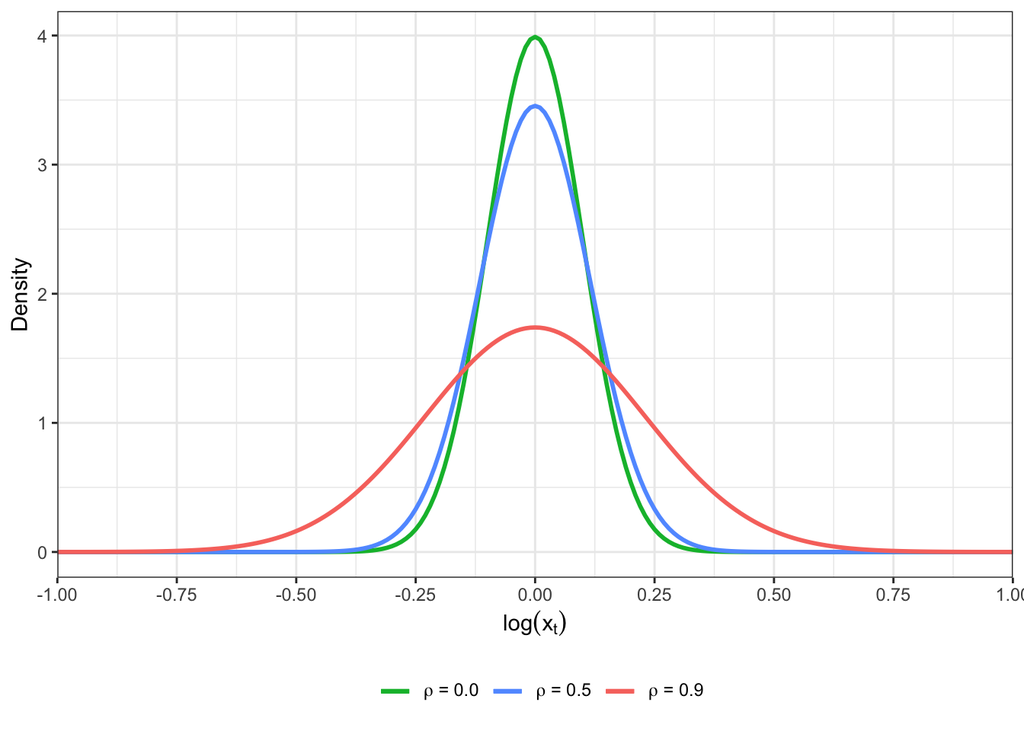

```r
x = seq(-1, 1, 0.01)
dat <- data.frame(x)

# iterate over different values
i <- 1
for(rho in c(0, 0.5, 0.9)) {
  dat[paste("rho", i, sep="")] <- dnorm(x, mean=0, sd=sd_eps/sqrt(1-rho^2))
  i <- i+1
}

# create plot for different values of rho
myplot <- ggplot(data = dat) +
  geom_line(aes(x=x, y=rho1, color="l1"), linewidth=1) +
  geom_line(aes(x=x, y=rho2, color="l2"), linewidth=1) +
  geom_line(aes(x=x, y=rho3, color="l3"), linewidth=1) +
  scale_x_continuous(breaks=seq(-1, 1, 0.25), expand=c(0, 0)) +
  labs(x = expression(log(x[t])),
       y = "Density") +
  scale_color_manual(breaks = c("l1", "l2", "l3"),
                     labels = c(expression(paste(rho," = 0.0")), expression(paste(rho," = 0.5")), expression(paste(rho," = 0.9"))),
                     values = c(mygreen, myblue, myred), name='') +
  theme_bw() +
  theme(legend.position="bottom")

# print the plot
print(myplot)
```

### Distribution for $X_t$ for different values of $\rho$

Now, we are interested in the distribution of $X_t$ (not $\log(X_t)$). While $\log(X_t)$ follows a simple normal distribution, $X_t = \exp(\log(X_t))$ has to follow a log-normal distribution. The distribution can just be calculated from taking the exponential of `x`. The log-normal distribution is bound from below by the value $0$. In addition, it is not symmetric anymore.

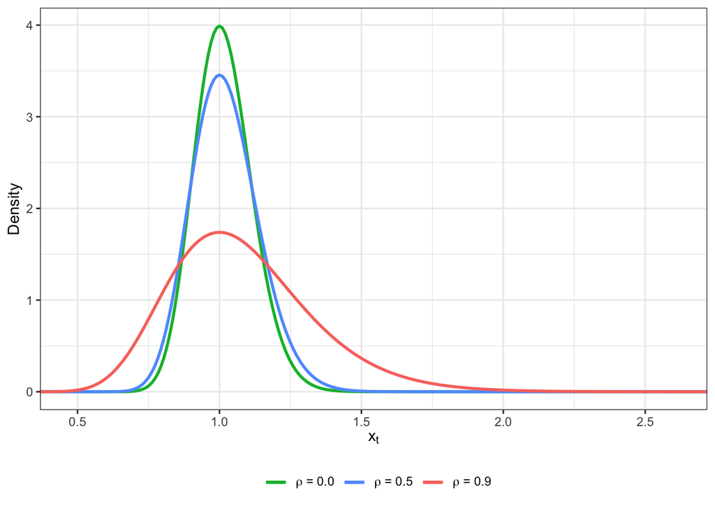

```r
# create plot for different values of rho
myplot <- ggplot(data = dat) +
  geom_line(aes(x=exp(x), y=rho1, color="l1"), linewidth=1) +
  geom_line(aes(x=exp(x), y=rho2, color="l2"), linewidth=1) +
  geom_line(aes(x=exp(x), y=rho3, color="l3"), linewidth=1) +
  scale_x_continuous(breaks=seq(0, 3, 0.5), expand=c(0, 0)) +
  labs(x = expression(x[t]),
       y = "Density") +
  scale_color_manual(breaks = c("l1", "l2", "l3"),
                     labels = c(expression(paste(rho," = 0.0")), expression(paste(rho," = 0.5")), expression(paste(rho," = 0.9"))),
                     values = c(mygreen, myblue, myred), name='') +
  theme_bw() +
  theme(legend.position="bottom")

# print the plot
print(myplot)
```

### Distribution for $\log(X_t)$ for different values of $\bar X$

Next, we keep the persistence parameter $\rho = 0.9$ constant and change the long-run mean $\bar X$ of the process. Increasing the mean shifts the distribution of $\log(X_t)$ to the right.

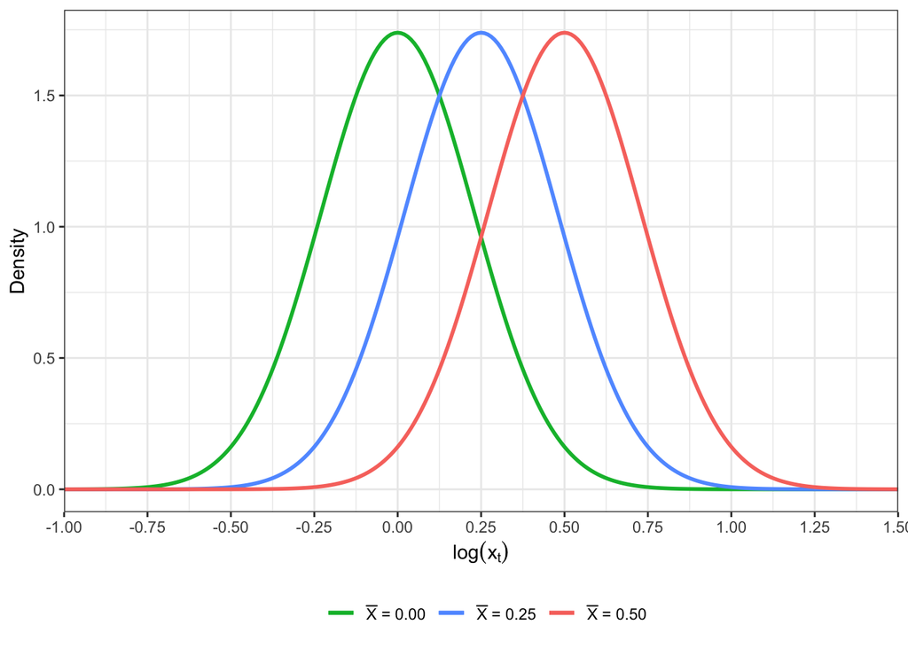

```r
rho = 0.9
x = seq(-1, 1.5, 0.01)
dat <- data.frame(x)

# iterate over different values
i <- 1
for(X_bar in c(0, 0.25, 0.5)) {
  y <- c(0:(length(x)-1))
  dat[paste("rho", i, sep="")] <- dnorm(x, mean=X_bar, sd=sd_eps/sqrt(1-rho^2))
  i <- i+1
}

# create plot for different values of rho
myplot <- ggplot(data = dat) +
  geom_line(aes(x=x, y=rho1, color="l1"), linewidth=1) +
  geom_line(aes(x=x, y=rho2, color="l2"), linewidth=1) +
  geom_line(aes(x=x, y=rho3, color="l3"), linewidth=1) +
  scale_x_continuous(breaks=seq(-1, 1.5, 0.25), expand=c(0, 0)) +
  labs(x = expression(log(x[t])),
       y = "Density") +
  scale_color_manual(breaks = c("l1", "l2", "l3"),
                     labels = c(expression(paste(bar(X)," = 0.00")), expression(paste(bar(X)," = 0.25")), expression(paste(bar(X)," = 0.50"))),
                     values = c(mygreen, myblue, myred), name='') +
  theme_bw() +
  theme(legend.position="bottom")

# print the plot
print(myplot)
```

### Distribution for $X_t$ for different values of $\bar X$

The same is true for the distribution of $X_t$.

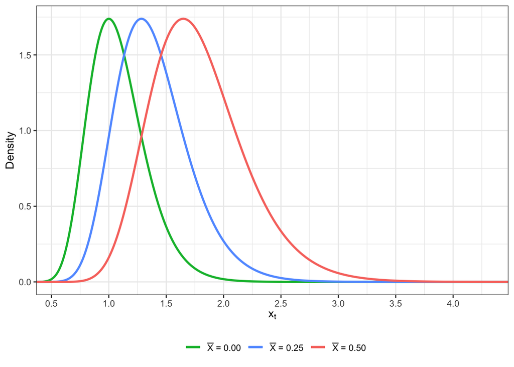

```r
# create plot for different values of rho
myplot <- ggplot(data = dat) +
  geom_line(aes(x=exp(x), y=rho1, color="l1"), linewidth=1) +
  geom_line(aes(x=exp(x), y=rho2, color="l2"), linewidth=1) +
  geom_line(aes(x=exp(x), y=rho3, color="l3"), linewidth=1) +
  scale_x_continuous(breaks=seq(0, 4.5, 0.5), expand=c(0, 0)) +

  labs(x = expression(x[t]),
       y = "Density") +
  scale_color_manual(breaks = c("l1", "l2", "l3"),
                     labels = c(expression(paste(bar(X)," = 0.00")), expression(paste(bar(X)," = 0.25")), expression(paste(bar(X)," = 0.50"))),
                     values = c(mygreen, myblue, myred), name='') +
  theme_bw() +
  theme(legend.position="bottom")

# print the plot
print(myplot)
```